# 01.01.02.00.Aplicaciones.AgujerosNegros.FenomenologiaBasica

Indice | Previo: Aplicaciones.AgujerosNegros.MetricaSchwarzschild | Siguiente: Aplicaciones.AgujerosNegros.Geodesicas

### 1.1.6. Coordenadas y medidas

La métrica de Schwarzschild,

$$ \mathrm{d}s^2=\left(1-\frac{R_S}{r}\right)\mathrm{d}T^2-\left(1-\frac{R_S}{r}\right)^{-1}\mathrm{d}r^2-\mathrm{d}{\ell}^2 $$

como cualquier otra métrica, nos permite calcular directamente la distancia entre eventos cercanos en el espacio-tiempo alrededor de un objeto esféricamente simétrico. Pero ¿qué significa esa distancia y como se relaciona con las *medidas* que pueden realizar distintos observadores que estudian la gravedad cerca al cuerpo?

Podemos reconocer 3 tipos básicos de observadores en un campo gravitacional:

1. **Observador en reposo**. Este observador no cambia sus coordenadas y esta en reposo respecto al centro del cuerpo. Naturalmente su reposo no es compatible con la estructura del espacio-tiempo que dicta que debería moverse en una geodésica que sabemos esta asociada con la caída libre. Para mantener su condición este observador debe usar un mecanismo externo, un cohete, una cuerda que le llega de mucho más arriba. Podemos considerar que *localmente* este observador percibe un espacio-tiempo plano, pero para hacer consistente sus observaciones del mundo debemos agregar a sus sistema de referencia una *fuerza* gravitacional que obliga a las cosas localmente a su alrededor a acelerarse hacia el centro. Usaremos el subíndice **st** (*static*) para representar las cantidades medidas por este observador.
1. **Observador en caída libre**. Otra posibilidad es estudiar los fenómenos mientras se describe una geodésica en el espacio-tiempo. Llamamos a este tipo de observador un *observador en caída libre*. De acuerdo con el principio de equivalencia, este observador es localmente inercial y no percibe los efectos del campo gravitacional. La métrica que percibe localmente es también la el espacio-tiempo plano. Una observación importante es que el observador en caída libre no esta en reposo respecto al centro del cuerpo que ve acercarse (o alejarse) a medida que se mueve en su geodésica. Usaremos el subíndice **ff** (*free-fall*) para representar las cantidades medidas por este observador.
1. **Observador remoto**. Un tipo de observador en caída libre muy útil es uno que se encuentra a una distancia muy grande del cuerpo. Este observador esta prácticamente en reposo respecto al cuerpo masivo. Dado que se encuentra muy lejos, pero también que está en caía libre la métrica que percibe es la métrica de Minkowski. Usaremos el subíndice "$\infty$" para representar las cantidades medidas por este observador.

La pregunta que nos hacemos es: ¿a qué observación de cuál observador corresponden los valores de las coordenadas de Schwarzschild, $(t, r, \theta, \phi)$?.

Este es uno de los aspectos más extraños (o nuevos respecto a nuestra visión clásica del mundo y de la física): la libertad que tenemos en relatividad general de elegir las coordenadas hace que sea físicamente irrelevante lo que significan las coordenadas anteriores. Estrictamente hablando $t$, por ejemplo, no corresponde necesariamente a un tiempo o $r$ a una distancia. Son solo etiquetas para nombrar los eventos alrededor del cuerpo que produce el campo gravitacional. Es posible que después de un cambio de coordenadas los tiempos medidos por un observador correspondan a una mezcla de valores de $t$ y $r$.

La coordenada temporal deja de ser tiempo, es solo una de 4 coordenadas.

Para definir rigurosamente las medidas de tiempo y distancia en cualquier métrica en un campo gravitacional debemos realizar experimentos. Solo los experimentos nos proveeran de la intuición básica de lo que pasa en un campo gravitacional.

### 1.1.7. Dilatación gravitacional del tiempo

Consideremos por ejemplo una situación en la que tenemos una fuente de luz situada en reposo en un punto del espacio con coordenadas $(r,\theta,\phi)$. Imaginemos que la fuente emite pulsos muy cortos de luz periódicamente (con una periodicidad tan pequeña como queramos).

Tomemos dos pulsos caracterizados por coordenadas de Schwarzschild $E_1:(t,r,\theta,\phi)$ y el fin de la emisión $E_2:(t+\mathrm{d}t_\mathrm{em},r,\theta,\phi)$, siendo aquí $\mathrm{d}t$ la diferencia (arbitrariamente pequeña) entre las coordenadas $t$ de los dos pulsos.

De acuerdo con la métrica de Schwarzschild la distancia espacio-temporal entre estos eventos será:

$$ \mathrm{d}s=\sqrt{1-\frac{R_S}{r}}\;c\mathrm{d}t_\mathrm{em} $$

De acuerdo con la relatividad general este intervalo debe ser el mismo para cualquier sistema de coordenadas construído alrededor del evento. En particular podemos usar el sistema de coordenadas de un observador en reposo al lado de la fuente de luz. Recordemos que para este observador la métrica local es Minkowskiana y dado que estamos considerando dos eventos que ocurren en el mismo lugar del espacio, entonces la separación espacio-temporal entre los eventos será igual (en unidades luz) al tiempo propio entre ellos medidos por el observado $\mathrm{d}\tau_\mathrm{st}^2$. De este modo:

$$ \mathrm{d}\tau_\mathrm{st}=\sqrt{1-\frac{R_S}{r}}\;\mathrm{d}t_\mathrm{em} $$

Aquí esta la primera evidencia de que las coordenadas de Schwarzschild en realidad no *necesariamente* corresponden a una medida hecha por un observador concreto. Ni siquiera un observador parado al lado de una fuente de luz mide el "tiempo" $\mathrm{d}t$.

Permitamos que la luz de la fuente se propague en todas direcciones. Nos interesa en particular un rayo de luz que se propaga en dirección radial hacia afuera ($\mathrm{d}{\ell}=0$). Al tratarse de un rayo de luz, los eventos que va visitando el rayo se encuentran separados entre sí por una distancia espacio-temporal nula:

$$ 0=\left(1-\frac{R_S}{r}\right)\mathrm{d}T^2-\left(1-\frac{R_S}{r}\right)^{-1}\mathrm{d}r^2 $$

De aquí podemos deducir la ecuación de movimiento del rayo de luz que sale hacia fuera, que podemos escribir, convenientemente, como:

$$ \frac{\mathrm{d} t}{\mathrm{d} r}=\frac{1}{c} \frac{1}{1-R_{\mathrm{S}} / r} $$

Si integramos entre el tiempo de emisión $t$ y un tiempo de detección $t_\mathrm{obs}$, en algún punto lejos del cuerpo, $r=r_\mathrm{obs}$, obtenemos:

$$ t_\mathrm{obs}-t=\frac{ r_\mathrm{obs}-r}{c} +\frac{c}{R_{\mathrm{S}}} \ln \left(\frac{r_\mathrm{obs}-R_{\mathrm{S}}}{r-R_{\mathrm{S}}} \right) $$

una expresión bastante complicada para algo tan sencillo como un rayo de luz saliendo del cuerpo.

La ecuación anterior representa la ecuación de una geodésica nula alrededor del cuerpo. En el código a continuación dibujamos geodésicas nulas alrededor de un cuerpo:

```python
%matplotlib inline
```

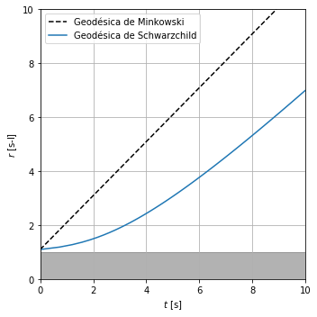

```python
#Condiciones iniciales
c=3e5 # km/s
RS=3e5 # km
r=1.1*RS

from numpy import linspace
robs=linspace(r,10*RS,100)

from numpy import log
tobs=(robs-r)/c+c/RS*log((robs-RS)/(r-RS))
tpla=(robs-r)/c

import matplotlib.pyplot as plt
fig=plt.figure(figsize=(5,5))
ax=fig.gca()
ax.axhspan(0,1,color='k',alpha=0.3)
ax.plot(tpla,robs/c,'k--',label='Geodésica de Minkowski')
ax.plot(tobs,robs/c,label='Geodésica de Schwarzchild')

#Decoración
ax.set_xlabel("$t$ [s]")
ax.set_ylabel("$r$ [s-l]")
ax.legend()
rang=max(robs/c)
ax.set_xlim((0,rang))
ax.set_ylim((0,rang))
ax.grid()
fig.tight_layout()
```

**Figura 1.5.**

Si tomamos dos pulsos de luz consecutivos separados por una diferencia coordenada de tiempo $\mathrm{d}t_\mathrm{em}$, emitidos desde la misma coordenada radial $r$, los tiempos de detección de estos pulsos en el lugar lejano, que podemos llamar $t_\mathrm{obs}$ y $t_\mathrm{obs}'$, serán:

\begin{eqnarray} \nonumber t_\mathrm{obs}-t & = & \frac{ r_\mathrm{obs}-r}{c} +\frac{c}{R_{\mathrm{S}}} \ln \left(\frac{r_\mathrm{obs}-R_{\mathrm{S}}}{r-R_{\mathrm{S}}} \right)\\ \nonumber t_\mathrm{obs}'-(t+\mathrm{d}t_\mathrm{em}) & = & \frac{ r_\mathrm{obs}-r}{c} +\frac{c}{R_{\mathrm{S}}} \ln \left(\frac{r_\mathrm{obs}-R_{\mathrm{S}}}{r-R_{\mathrm{S}}} \right)\\ \end{eqnarray}

De modo que la diferencia entre las coordenadas temporales en el lugar lejano $\mathrm{d}t_\mathrm{obs}=t_\mathrm{obs}'-t_\mathrm{obs}$ será:

$$ \mathrm{d}t_\mathrm{obs}=\mathrm{d}t_\mathrm{em} $$

esto, sin importar la distancia a la que se encuentre el observador.

Este resultado aplica incluso si los eventos tienen una separación macroscópica:

$$ \Delta t_\mathrm{obs}=\Delta t_\mathrm{em} $$

Esta igualdad se puede ilustrar graficando multiples rayos de luz:

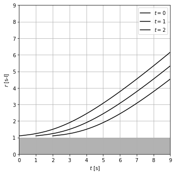

**Figura 1.6.** Geodésica nula de rayos de luz que viajan radialmente hacia afuera desde el mismo punto.

Puede verse que independientemente de la trayectoria que sigan los rayos de luz, la separación entre ellos al llegar a un observador lejano será siempre la misma (1 segundo).

En particular para el observador remoto, que definíamos al principio, el tiempo medido y el tiempo coordenado entre los dos eventos de llegada de los pulsos será igual, de modo que concluímos que:

$$ \Delta\tau_\mathrm{\infty}=\Delta t_\mathrm{em} $$

Es decir, podemos relacionar los intervalos de tiempo coordenado (en coordenadas de Schwarzschild) entre eventos en el mismo lugar del espacio, con el tiempo medido por relojes de un observador remoto.

Esto finalmente implica la relación:

$$ \Delta\tau_\mathrm{st}=\sqrt{1-\frac{R_S}{r}}\;\Delta\tau_\mathrm{\infty} $$

Que se escribe más convenientemente como:

$$ \Delta\tau_\mathrm{\infty}=\frac{1}{\sqrt{1-R_S/r}}\;\Delta\tau_\mathrm{st} $$

Si definimos $\rho=r/R_S$ y:

$$ \Gamma(\rho)\equiv\frac{1}{\sqrt{1-1/\rho}} $$

en clara analogía con el factor de Lorentz-Einstein de la relatividad especial $\gamma=(1-v^2/c^2)^{-1/2}$, entonces la anterior expresión se escribe como:

$$ \Delta\tau_\mathrm{\infty}=\Gamma(\rho)\;\Delta\tau_\mathrm{st} $$

Como vemos el tiempo *observado* entre dos eventos que ocurren en la misma coordenada $r$ alrededor del cuerpo es siempre mayor que el tiempo *propio* registrado entre estos dos eventos por un observador en reposo al lado del fenómeno. Llamamos a este fenómeno **dilatación gravitacional del tiempo**.

Hagamos un cálculo típico. Por ejemplo supongamos que tenemos un fenomeno magnético (una región de actividad) que se desarrolla en la superficie del Sol (que suponemos aproximadamente quieto y simétricamente esférica) durante 1 mes o $2.6\times 10^{6}$ segundos. Cuánto dura el mismo fenómeno *visto* desde la Tierra:

```python
#Radio de Schwarzschild del Sol
RS=3 # km

#Radio del Sol
r=7e5 # km

rho=r/RS

#Duración "propia" del fenómeno
dtst=2.6e6 # s

#Factor de dilatación
from numpy import sqrt
G=1/sqrt(1-1/rho)

#Duración del fenómeno para un observador remoto
dtin=G*dtst

#Diferencia de tiempo
Dt=dtin-dtst
```

```
El fenómeno visto desde la Tierra dura 5.571446479763836 segundos mas
```

Como vemos, más interesante que la dilatación misma es la diferencia entre el tiempo medido remotamente y el tiempo propio del fenóemno:

$$ \Delta\tau_\mathrm{\infty}-\Delta\tau_\mathrm{st}=[\Gamma(\rho)-1]\;\Delta\tau_\mathrm{st} $$

**Nota: Expresión aproximada para $\Gamma$.** Una forma muy conveniente para escribir $\Gamma(\rho)$ se obtiene cuando el lugar en el que se produce la luz esta a una distancia $r\gg R_S$, es decir $\rho\gg 1$. En este caso:

> $$ \Gamma(\rho)\approx 1+\frac{1}{2\rho} $$

> o bien,

> $$ \Gamma(\rho)-1\approx \frac{1}{2\rho} $$

> Usando el hecho que $R_S=2GM/c^2$ y definiendo $\Phi(r,M)\equiv -GM/r$ o bien $\Phi(\rho)=-c^2/(2\rho)$ (potencial gravitacional clásico), entonces:

> $$ \Gamma(\rho)\approx 1-\frac{\Phi(\rho)}{c^2} $$

> o lo que es lo mismo:

> $$ \Gamma(\rho)-1\approx -\frac{\Phi(\rho)}{c^2} $$

En la figura a continuación se muestra el valor de $\Gamma(\rho)$ para distintos valores de la razón $\rho=r/R_S$.

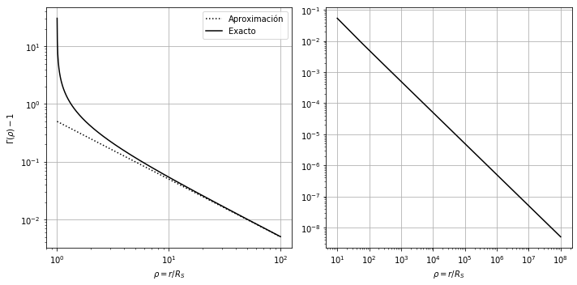

### 1.1.8. Corrimiento al rojo gravitacional

No es difícil convertir el resultado anterior en los cambios que sufre un rayo de luz monocromático que se propaga radialmente en la métrica de Schwarzschild.

Si tomamos $\Delta\tau_\mathrm{st}=P_\mathrm{em}$, donde $P_\mathrm{em}$ es el período de una onda monocromática, entonces:

$$ P_\mathrm{\infty}=\Gamma(\rho)\;P_\mathrm{em} $$

La frecuencia $f$ de la onda será:

$$ f_\mathrm{\infty}=\frac{1}{\Gamma(\rho)}\;f_\mathrm{em} $$

Es decir lejos del cuerpo la frecuencia percibida será menor que la frecuencia emitida. La longitud de onda, por otro lado, será:

$$ \lambda_\mathrm{\infty}=\Gamma(\rho)\;\lambda_\mathrm{em} $$

En términos de $\Gamma$ el corrimiento al rojo $z\equiv(\lambda_\mathrm{obs}-\lambda_\mathrm{em})/\lambda_\mathrm{em}$, se puede escribir como:

$$ z_\infty=\Gamma(\rho)-1 $$

que es justamente la cantidad graficada más arriba.

Como vemos el corrimiento al rojo para cuerpos astrofísicos relativamente normales para los cuales $\rho\gg 1$, es muy pequeño y difícil de detectar.

El primer intento por medir el corrimiento al rojo gravitacional se realizó en los 1925 con la enana blanca Sirio B. Podemos calcular la magnitud del corrimiento esperado para esta estrella. Para ello lo podemos parametrizar, como se acostumbra en astronomía, en términos de una velocidad usando $v_z=c z$:

```python
# Radio de Schwarzchild
RS=3 # km

# Radio de la estrella
r=1e4 # km

# Velocidad de la luz
c=3e5

# Factor Gamma
from numpy import sqrt
rho=r/RS
G=1/sqrt(1-1/rho)

# Corrimiento al rojo
z=(G-1)
vz=z*c
```

```
Corrimiento esperado para Sirius B: 45.01 km/s
```

Lamentablemente por problemas de contaminación la medida no fue posible en aquella época y solo hasta 1954 logro medirse el corrimiento en la enana blanca Epsilon Eridani B.

En situaciones realistas las observaciones se hacen con observadores situados a distancias finitas. En este caso:

\begin{eqnarray} \nonumber \Delta\tau_\mathrm{\infty} & = & \Gamma(\rho_1)\;\Delta\tau^{(1)}_\mathrm{st}\\ \nonumber \Delta\tau_\mathrm{\infty} & = & \Gamma(\rho_2)\;\Delta\tau^{(2)}_\mathrm{st} \end{eqnarray}

De aquí que:

$$ \Delta\tau^{(2)}_\mathrm{st}=\frac{\Gamma(\rho_1)}{\Gamma(\rho_2)}\Delta\tau^{(1)}_\mathrm{st} $$

Y por lo tanto la fórmula del corrimiento al rojo gravitacional será:

$$ \lambda_\mathrm{obs}=\frac{\Gamma(\rho_1)}{\Gamma(\rho_2)}\lambda_\mathrm{em} $$

En términos explícitos:

$$ \lambda_\mathrm{obs}=\sqrt{\frac{1+2\Phi(\rho_2)/c^2}{1+2\Phi(\rho_1)/c^2}}\lambda_\mathrm{em} $$

Para valores $\Phi\ll c$, se puede usar la expansión:

$$ \frac{\lambda_\mathrm{obs}}{\lambda_\mathrm{em}}\approx 1+\frac{[\Phi(\rho_2)-\Phi(\rho_1)]}{c^2} $$

o en términos del corrimiento al rojo $z\equiv(\lambda_\mathrm{obs}-\lambda_\mathrm{em})/\lambda_\mathrm{em}$:

$$ z\approx \frac{\Phi(\rho_2)-\Phi(\rho_1)}{c^2} $$

### 1.1.9. Contracción de longitudes

Otro interesante pero muy sutil efecto geométrico en un espacio con la métrica de Schwarzschild es el que es conocido como la contracción gravitacional de longitudes.

Para introducir este efecto tomemos eventos en las vecindades del cuerpo que comparten la misma coordenada temporal. Así por ejemplo podemos tomar dos eventos con coordenadas $E_1:(t,r,\theta,\phi)$ y $E_2:(t,r,\theta+\mathrm{d}\theta,\phi+\mathrm{d}\phi)$. La distancia entre estos eventos será:

$$ \mathrm{d}s^2=-\mathrm{d}\ell^2 $$

donde:

$$ \mathrm{d}\ell^2=r^2\mathrm{d}\theta^2+r^2\sin^2\theta \mathrm{d}\phi^2 $$

Es decir los puntos se encuentran ubicados sobre una triesfera. La distancia entre esos puntos obedecera las reglas habituales de la trigonometría esférica. Es decir en superficies de $t$ y $r$ constantes en el espacio de Shcwarzschild la geomtería es convencional.

En particular podemos calcular la longitud $C$ de una circunferencia máxima y obtenemos el resultado habitual:

$$ C=2\pi r $$

Todo parece muy normal para ser cierto. ¿Dónde esta la sutileza?. La sutileza está en pensar que $r_0$ es la distancia al centro de la distribución de materia. Recordemos que $r_0$ es solo una de las partes de la etiqueta que usamos para indicar la posición de eventos alrededor del cuerpo y no corresponde con una cantidad medida realmente. Sin embargo $C$ si que es una cantidad real, medible: podemos usar reglas en el sistema de referencia en reposo, orientadas en dirección perpendicular a la "fuerza" de gravedad para medir $C$. Aquí aparece un resultado interesante y es que midiendo $C$ podemos determinar $r$:

$$ r=\frac{C}{2\pi} $$

Imaginemos ahora dos eventos $E_1:(t,r,\theta,\phi)$, $E_2:(t,r+\mathrm{d}r,\theta,\phi)$ situados en una misma dirección radial. La distancia espacio temporal entre los eventos es ahora:

$$ \mathrm{d}s^2=-\left(1-\frac{R_S}{r}\right)^{-1}\mathrm{d}r^2 $$

El observador en reposo al lado de los dos eventos y situado en $r$ la *distancia* entre los eventos será, $\mathrm{d}s^2=-\mathrm{d}r_\mathrm{st}^2$ donde $r_\mathrm{st}$ es una coordenada radial usada localmente por el observador a lo largo de la dirección radial:

$$ \mathrm{d}r_\mathrm{st}=\frac{\mathrm{d}r}{\sqrt{1-\frac{R_S}{r}}} $$

es decir:

$$ \mathrm{d}r=\sqrt{1-\frac{R_S}{r}}\mathrm{d}r_\mathrm{st} $$

Es decir, si muchos observadores se ponen de acuerdo para poner una barra de longitud igual $\mathrm{d}r_\mathrm{st}$ en dirección radial entre ellos, la separación en la coordenada radial entre los observadores no será uniforme. Cerca $R_S$ será menor y muy lejos de él será mayor.

El observador remoto puede realizar una tarea similar. Conociendo donde esta la fuente de materia, construye un sistema de coordenadas cuyo origen coincide con la distribución de materia y usa también coordenadas esféricas. Ese observador aplica sobre el espacio tiempo de todo el universo (incorrectamente) la métrica de Minkowski (el juzga que todo puede medirse con sus estándares). De nuevo, la distancia entre esos dos eventos las juzga igual a $\mathrm{d}s^2=-\mathrm{d}r_\mathrm{\infty}^2$. Dado que la distancia espacio-temporal debe coincidir:

$$ \mathrm{d}r_\mathrm{\infty}=\frac{\mathrm{d}r}{\sqrt{1-\frac{R_S}{r}}} $$

La distancia finita $\Delta r_\infty$, medida por el observador remoto, entre dos circunferencias concentricas con coordenadas de Schwarzschild $r_1$ y $r_2$ se obtiene integrando:

$$ \Delta \rho_\infty=\left\{\rho\sqrt{1-\frac{1}{\rho}}+\frac{1}{2} \log \left[2 \rho\left(\sqrt{1-\frac{1}{\rho}}+1\right)-1\right]\right\}_{\rho_{1}}^{\rho_{2}} $$

donde hemos usado aquí la variable radial normalizada $\rho=r/R_S$

De aquí vemos que la distancia medida desde $\rho_1=1$ a cualquier coordenada $\rho_2=\rho$ es:

$$ \Delta \rho_\infty=\rho\sqrt{1-\frac{1}{\rho}}+\frac{1}{2} \log \left[2 \rho\left(\sqrt{1-\frac{1}{\rho}}+1\right)-1\right] $$

Ciertamente esta es una expresión mucho más complicada que $\Delta \rho_\infty$. Para entenderla mejor hagamos un gráfico:

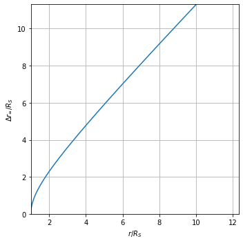

```python
from numpy import linspace,sqrt,log
rho=linspace(1,10,1000)
drho_inf=rho*sqrt(1-1/rho)+0.5*log(2*rho*(sqrt(1-1/rho)+1)-1)

import matplotlib.pyplot as plt
fig=plt.figure(figsize=(5,5))
ax=fig.gca()

ax.plot(rho,drho_inf)

#Decoración
ax.grid()

ax.set_xlabel(r"$r/R_S$")
ax.set_ylabel(r"$\Delta r_\infty/R_S$")

rang=max(drho_inf)
ax.set_xlim((1,rang+1))
ax.set_ylim((0,rang))
fig.tight_layout()
```

**Figura 1.8.**

Indice | Previo: Aplicaciones.AgujerosNegros.MetricaSchwarzschild | Siguiente: Aplicaciones.AgujerosNegros.Geodesicas